# Project Regresi Linear Berganda

Sandra Berliana Putri - G1401221021

2024-04-21

```r
library(readxl)
library(dplyr)
library(lmtest)
library(GGally)
library(randtests)
library(nortest)
library(MASS)
library(car)
library(olsrr)
library(tidyverse)
```

# Data

Menggunakan data dengan peubah sebagai berikut :  
$Y$ = Indeks Demokrasi  
$X_1$= Indeks Kemerdekaan Pers  
$X_2$ = Jumlah Ormas/LSM  
$X_3$ = Jumlah Aturan Yang Membatasi Kebebasan  
$X_4$ = Persentase Perempuan di DPRD  
$X_5$ = IPM  
$X_6$ = PDRB (Ribu Rupiah)  
$X_7$ = Indeks Keterbukaan Informasi Publik  
$X_8$ = Indeks Pembangunan Gender  
$X_9$ = Nilai Integritas Pemerintah

```r
Data_Anreg <- read_excel("C:\\Users\\ASUS\\Downloads\\Data_Anreg_Kel 9.xlsx")
head(Data_Anreg)
```

```
## # A tibble: 6 × 10
##       Y    X1    X2    X3    X4    X5     X6    X7    X8    X9
##   <dbl> <dbl> <dbl> <dbl> <dbl> <dbl>  <dbl> <dbl> <dbl> <dbl>
## 1  80.8  76.4   238     2 11.1   72.8  38900  79.1  92.2  63.4
## 2  79.5  75.9   676     3 13     72.7  62922  73.4  91.1  66.2
## 3  77.4  78.7   204    16  6.15  73.3  50264  75.4  94.7  70.6
## 4  73.6  82.0   334     3 18.5   73.5 151259  76.7  88.7  64.2
## 5  77.2  83.7   139     4 14.6   72.1  76164  74.0  89.0  69.4
## 6  80.6  81.4   200     2 21.3   70.9  68237  71.0  93.0  65.6
```

## Model Awal

```r
model1<- lm(Y~. , data= Data_Anreg)
summary(model1)
```

```
##
## Call:
## lm(formula = Y ~ ., data = Data_Anreg)
##
## Residuals:
##     Min      1Q  Median      3Q     Max
## -5.7352 -1.8433  0.2983  2.0116  5.7584
##
## Coefficients:
##               Estimate Std. Error t value Pr(>|t|)
## (Intercept) -4.220e+01  1.964e+01  -2.149   0.0419 *
## X1           4.323e-01  2.055e-01   2.103   0.0461 *
## X2           5.024e-03  2.213e-03   2.270   0.0325 *
## X3          -4.704e-02  1.811e-01  -0.260   0.7973
## X4           1.330e-02  8.483e-02   0.157   0.8768
## X5           4.199e-01  2.960e-01   1.418   0.1690
## X6          -4.197e-06  1.460e-05  -0.288   0.7762
## X7           1.188e-01  1.681e-01   0.707   0.4866
## X8           3.528e-01  2.776e-01   1.271   0.2159
## X9           1.984e-01  1.275e-01   1.556   0.1329
## ---
## Signif. codes:  0 '***' 0.001 '**' 0.01 '*' 0.05 '.' 0.1 ' ' 1
##
## Residual standard error: 3.236 on 24 degrees of freedom
## Multiple R-squared:  0.7419, Adjusted R-squared:  0.6451
## F-statistic: 7.666 on 9 and 24 DF,  p-value: 3.146e-05
```

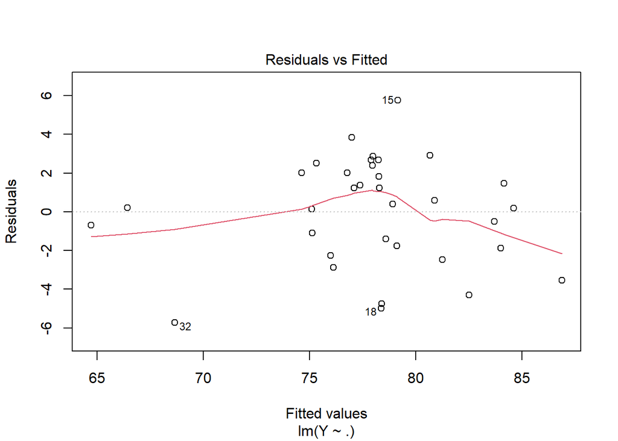

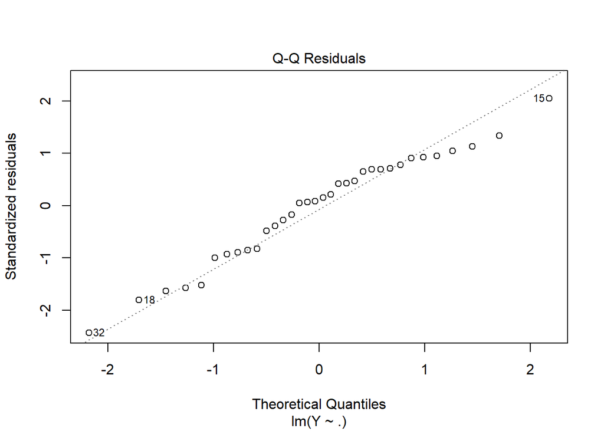

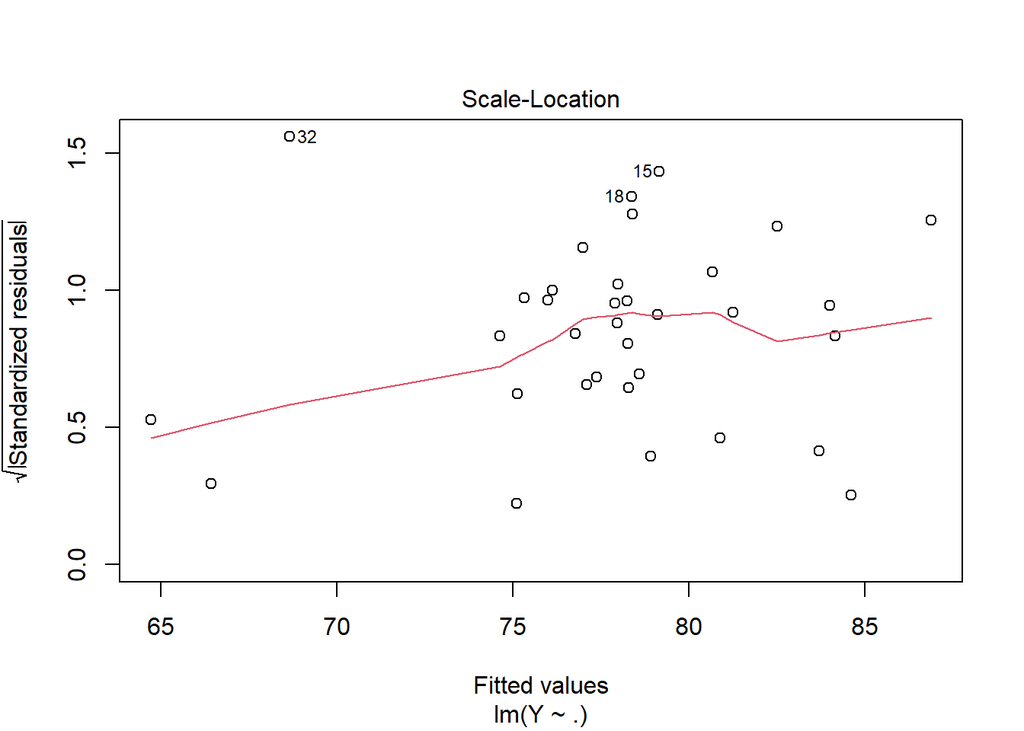

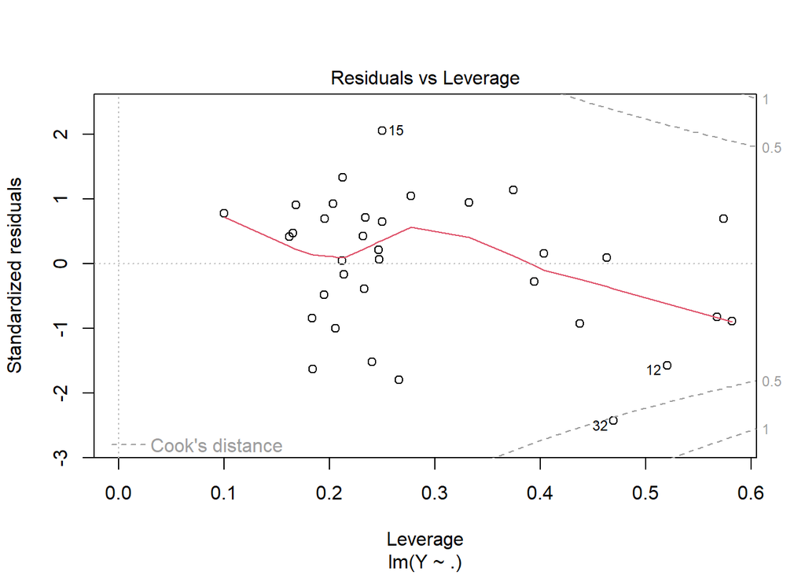

```r
plot(model1)
```

# Eksplorasi Data

```r
summary(Data_Anreg$Y)
```

```
##    Min. 1st Qu.  Median    Mean 3rd Qu.    Max.
##   62.93   75.61   78.78   77.95   80.91   85.62
```

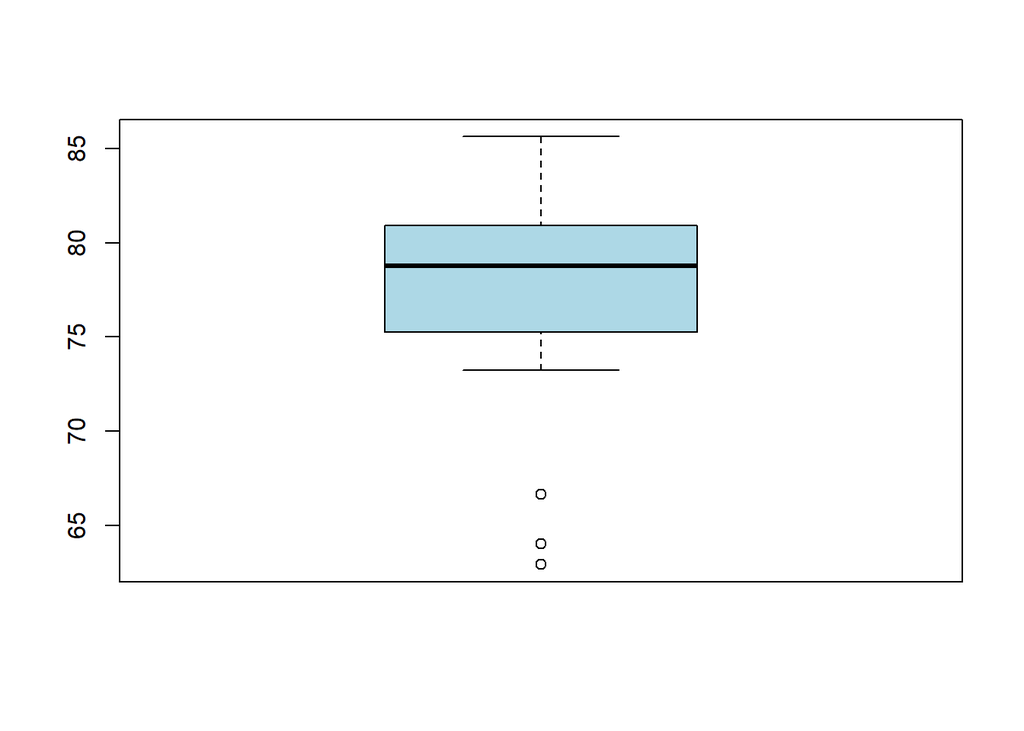

```r
boxplot(Data_Anreg$Y, col = "lightblue")
```

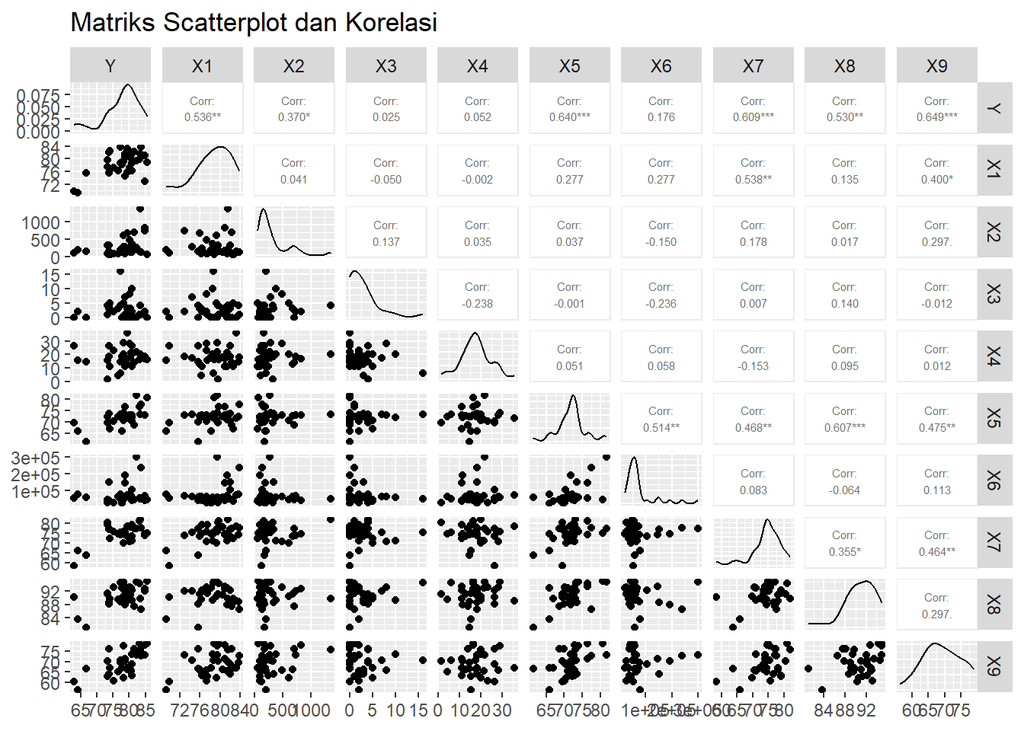

```r
ggpairs(Data_Anreg,
        upper = list(continuous = wrap('cor', size = 2)),
        title = "Matriks Scatterplot dan Korelasi")
```

Pada matriks diatas tanda * artinya nilai p-value < 0.05, yang artinya terdapat nilai korelasi antara 2 peubah. Pada matriks tersebut, peubah-peubah yang memiliki korelasi terhadap respon Y adalah X1, X2, X5, X7, X8, X9. Sedangkan peubah X3, X4, X6 tidak berkorelasi signifikan dengan Y sehingga dapat dikeluarkan dari model. X8 juga dapat dikeluarkan dari model dikarenakan korelasi yang tinggi dengan peubah X5.

```r
model2= lm(Y~X1+X2+X5+X7+X9 , data=Data_Anreg)
summary(model2)
```

```
##
## Call:
## lm(formula = Y ~ X1 + X2 + X5 + X7 + X9, data = Data_Anreg)
##
## Residuals:
##     Min      1Q  Median      3Q     Max
## -5.8704 -2.4087  0.2841  1.9428  5.9382
##
## Coefficients:
##               Estimate Std. Error t value Pr(>|t|)
## (Intercept) -19.062627  14.174112  -1.345  0.18945
## X1            0.381941   0.189058   2.020  0.05302 .
## X2            0.004925   0.002122   2.322  0.02776 *
## X5            0.540278   0.172446   3.133  0.00403 **
## X7            0.162398   0.153261   1.060  0.29837
## X9            0.209361   0.123018   1.702  0.09986 .
## ---
## Signif. codes:  0 '***' 0.001 '**' 0.01 '*' 0.05 '.' 0.1 ' ' 1
##
## Residual standard error: 3.185 on 28 degrees of freedom
## Multiple R-squared:  0.7084, Adjusted R-squared:  0.6564
## F-statistic: 13.61 on 5 and 28 DF,  p-value: 8.922e-07
```

# Pengujian Multikolinearitas

```r
vif(model2)
```

```
##       X1       X2       X5       X7       X9
## 1.493739 1.142603 1.472333 1.761202 1.638213
```

Melalui uji vif didapatkan nilai VIF dari tiap peubah yang tersisa kurang dari 10 sehingga dapat disimpulkan bahwa tidak terdapat multikolinearitas

# Pendeteksian pencilan, leverage, dan amatan berpengaruh

```r
index <- c(1:34)
ri <- studres(model2)
DFFITSi <- dffits(model2)
hii <- hatvalues(model2)
hasil <- data.frame(index,ri,DFFITSi,hii); round(hasil,4)
```

```
##    index      ri DFFITSi    hii
## 1      1  1.4449  0.6770 0.1800
## 2      2  0.3973  0.1573 0.1355
## 3      3 -0.3988 -0.0813 0.0399
## 4      4 -2.1074 -0.8531 0.1408
## 5      5 -0.6354 -0.2402 0.1251
## 6      6  1.3550  0.4820 0.1123
## 7      7 -0.9434 -0.4404 0.1789
## 8      8  0.5977  0.3037 0.2052
## 9      9  0.4201  0.1213 0.0769
## 10    10 -0.7436 -0.2533 0.1039
## 11    11 -0.8783 -0.4853 0.2339
## 12    12 -1.8877 -1.8739 0.4963
## 13    13  0.3556  0.1783 0.2008
## 14    14  0.7467  0.4783 0.2910
```

[output cut: 20 more lines]

```r
for (i in 1:dim(hasil)[1]){
  absri <- abs(hasil$ri)
  pencilan <- which(absri > 2)
}
pencilan
```

```
## [1]  4 15 32
```

```r
titik_leverage <- vector("list", dim(hasil)[1])
for (i in 1:dim(hasil)[1]) {
  cutoff <- 2 * 6/ 34
  titik_leverage[[i]] <- which(hii > cutoff)
}


leverages <- unlist(titik_leverage)
titik_leverage <- sort(unique(leverages))
titik_leverage
```

```
## [1] 12 32 34
```

```r
amatan_berpengaruh <- vector("list", dim(hasil)[1])
for (i in 1:dim(hasil)[1]) {
  cutoff <- 2 * sqrt((6/ 34))
  amatan_berpengaruh[[i]] <- which(abs(DFFITSi) > cutoff)
}
berpengaruh <- unlist(amatan_berpengaruh)
amatan_berpengaruh <- sort(unique(berpengaruh))
amatan_berpengaruh
```

```
## [1]  4 12 15 32
```

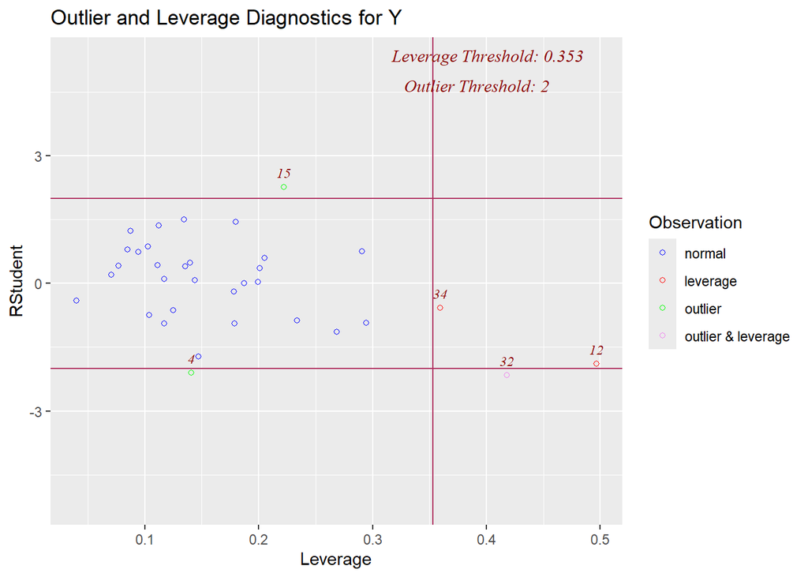

```r
ols_plot_resid_lev(model2)
```

Dari proses analisis sebelumnya didapatkan 3 buah pencilan yaitu amatan ke-4, ke-15, dan ke-32(Riau, Jawa Timur, Maluku Utara). Terdapat pula 3 buah leverage yaitu amatan ke-12, ke-32, dan ke-34 (Jawa Barat, Maluku Utara, dan Papua). dan 4 buah amatan berpengaruh yaittu amatan ke-4, ke-12, ke-15, dan amatan ke-32. Saat dicobakan nilai adj R-square tertinggi didapatkan dengan menghapus amatan ke-4, ke-12, dan ke-15

```r
# model dengan mengeluarkan amatan ke-4, ke-12 dan ke-15
db1= Data_Anreg[-c(34),]
db= Data_Anreg[-c(4,15,12),]
model3 = lm(Y~X1+X2+X5+X7+X9 , data=db)
summary(model3)
```

```
##
## Call:
## lm(formula = Y ~ X1 + X2 + X5 + X7 + X9, data = db)
##
## Residuals:
##     Min      1Q  Median      3Q     Max
## -5.3766 -1.3634 -0.1341  1.7843  4.4156
##
## Coefficients:
##               Estimate Std. Error t value Pr(>|t|)
## (Intercept) -34.549356  12.210193  -2.830  0.00906 **
## X1            0.623983   0.169406   3.683  0.00111 **
## X2            0.007434   0.002465   3.016  0.00581 **
## X5            0.579666   0.142637   4.064  0.00042 ***
## X7            0.201312   0.128735   1.564  0.13044
## X9            0.067596   0.107376   0.630  0.53472
## ---
## Signif. codes:  0 '***' 0.001 '**' 0.01 '*' 0.05 '.' 0.1 ' ' 1
##
## Residual standard error: 2.607 on 25 degrees of freedom
## Multiple R-squared:  0.806,  Adjusted R-squared:  0.7672
## F-statistic: 20.77 on 5 and 25 DF,  p-value: 3.57e-08
```

```r
anova(model3)
```

```
## Analysis of Variance Table
##
## Response: Y
##           Df Sum Sq Mean Sq F value    Pr(>F)
## X1         1 397.25  397.25 58.4561 5.313e-08 ***
## X2         1  64.21   64.21  9.4487  0.005053 **
## X5         1 222.63  222.63 32.7595 5.810e-06 ***
## X7         1  18.98   18.98  2.7935  0.107122
## X9         1   2.69    2.69  0.3963  0.534717
## Residuals 25 169.89    6.80
## ---
## Signif. codes:  0 '***' 0.001 '**' 0.01 '*' 0.05 '.' 0.1 ' ' 1
```

# Uji asumsi

Pengujian asumsi dilakukan dengan metode non-formal menggunakan visualisasi dan metode formal. Pada analisis regresi terdapat beberapa asumsi yang harus dipenuhi yaitu :

## Nilai Harapan sisaan 0 (E[e]=0)

H0: $E[\epsilon]=0$

H1: $E[\epsilon]\not=0$

### Non-Formal

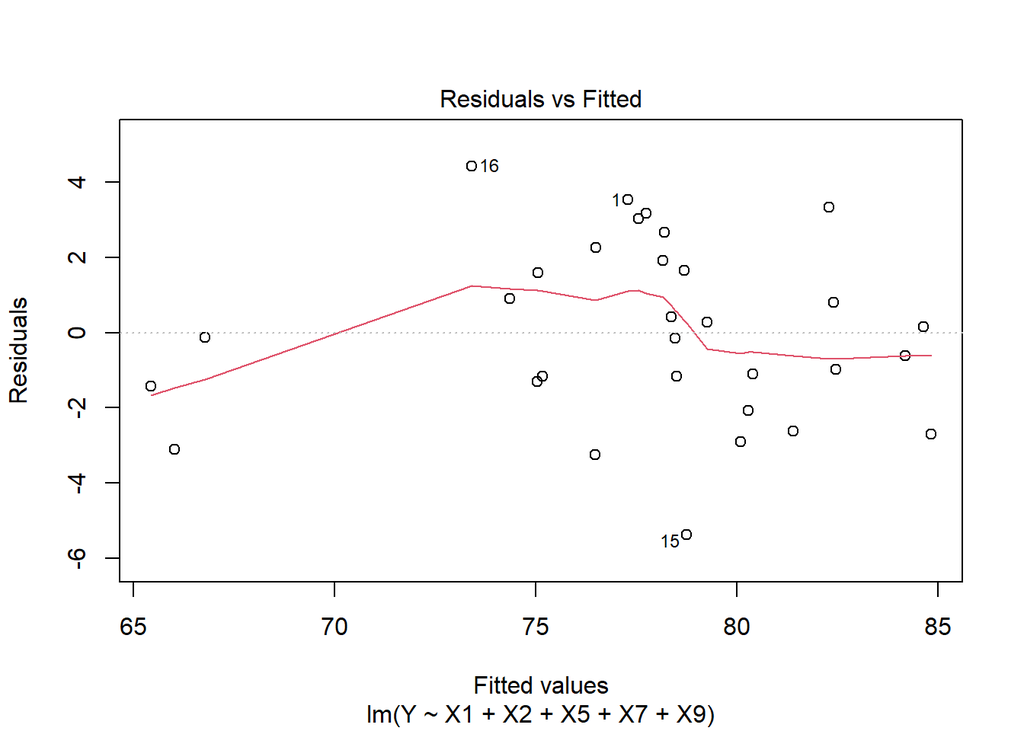

```r
plot(model3,1)
```

Terlihat sisaan menyebar disekitar 0 sehingga nilai harapan sisaan 0

### Formal

```r
t.test(model3$residuals,mu = 0,conf.level = 0.95)
```

```
##
##  One Sample t-test
##
## data:  model3$residuals
## t = 1.6741e-17, df = 30, p-value = 1
## alternative hypothesis: true mean is not equal to 0
## 95 percent confidence interval:
##  -0.872893  0.872893
## sample estimates:
##    mean of x
## 7.155297e-18
```

Uji-T menghasilkan p-value 1 > dibanding 0.05 sehingga pada taraf 5% H0 tidak ditolak. Asumsi nilai harapan sisaan 0 terpenuhi.

## Ragam sisaan homogen (Homoscedasticity)

H0: $Var[\epsilon]=\sigma^2 I$

H1: $Var[\epsilon]\not=\sigma^2 I$

### Non-Formal

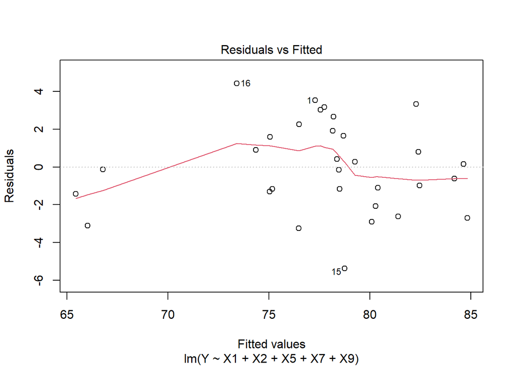

```r
plot(model3,1)
```

Lebar pita hampir sama untuk setiap dugaan sehingga asumsi kehomogenan ragam terpenuhi

### Formal

```r
bptest(model3)
```

```
##
##  studentized Breusch-Pagan test
##
## data:  model3
## BP = 2.4192, df = 5, p-value = 0.7886
```

## Sisaan saling bebas/ tidak ada autokorelasi

H0: $E[\epsilon_i , \epsilon_j]=0$

H1: $E[\epsilon_i , \epsilon_j]\not=0$

### Non-Formal

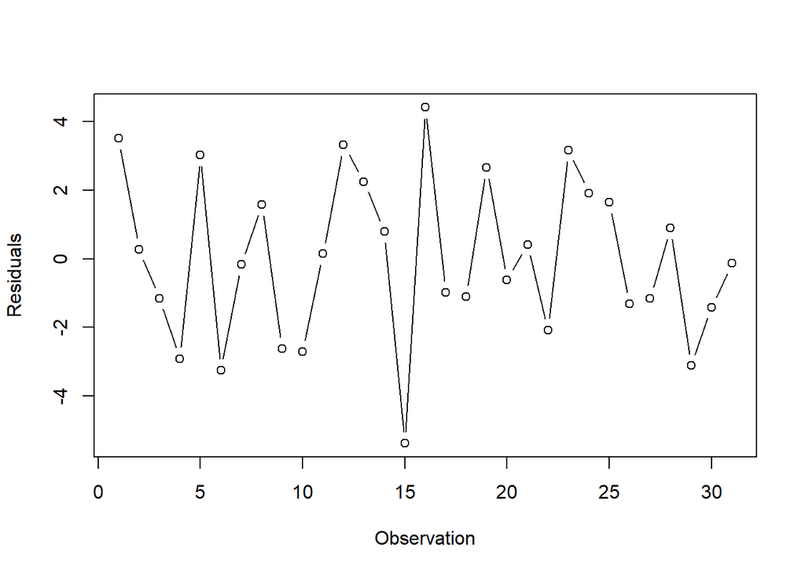

```r
plot(x = 1:dim(db)[1],
     y = model3$residuals,
     type = 'b',
     ylab = "Residuals",
     xlab = "Observation")
```

Melalui plot sisaan dan urutan dapat dilihat bahwa data menyebar acak dan tidak berpola. Sehingga tidak terdapat autokorelasi pada data

### Formal

```r
dwtest(model3)
```

```
##
##  Durbin-Watson test
##
## data:  model3
## DW = 2.3538, p-value = 0.7988
## alternative hypothesis: true autocorrelation is greater than 0
```

## Sisaan menyebar normal

H0: Sisaan menyebar normal

H1: Sisaan tidak menyebar normal

### Non-Formal

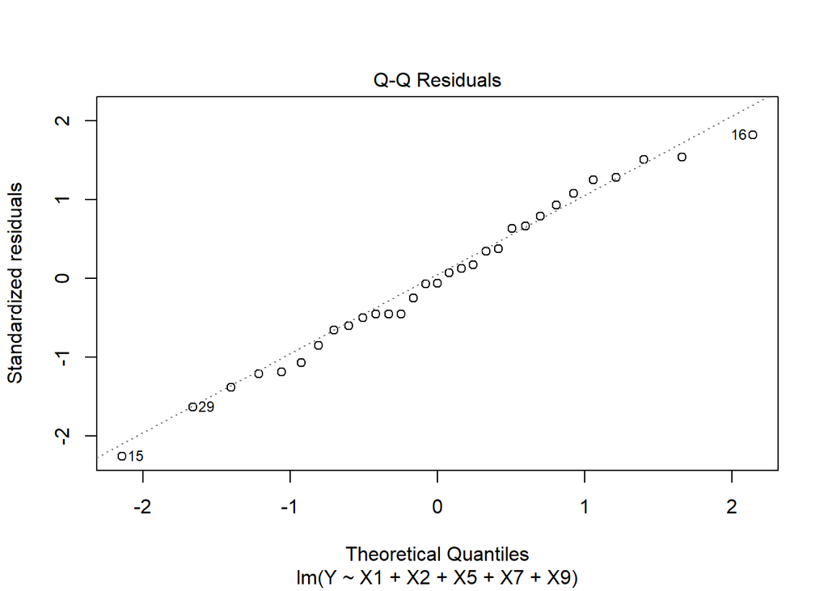

```r
plot(model3,2)
```

Melalui grafik tersebut terlihat data mengikuti garis, sehingga asumsi kenormalan sisaan terpenuhi.

### Formal

```r
ks.test(model3$residuals, "pnorm", mean=mean(model3$residuals), sd=sd(model3$residuals))
```

```
##
##  Exact one-sample Kolmogorov-Smirnov test
##
## data:  model3$residuals
## D = 0.079584, p-value = 0.9806
## alternative hypothesis: two-sided
```

# Pemilihan model terbaik

## Forward

```r
step(model3,direction="forward")
```

```
## Start:  AIC=64.74
## Y ~ X1 + X2 + X5 + X7 + X9
```

```
##
## Call:
## lm(formula = Y ~ X1 + X2 + X5 + X7 + X9, data = db)
##
## Coefficients:
## (Intercept)           X1           X2           X5           X7           X9
##  -34.549356     0.623983     0.007434     0.579666     0.201312     0.067596
```

## Backward

```r
step(model3,direction="backward")
```

```
## Start:  AIC=64.74
## Y ~ X1 + X2 + X5 + X7 + X9
##
##        Df Sum of Sq    RSS    AIC
## - X9    1     2.693 172.59 63.224
## <none>              169.89 64.737
## - X7    1    16.618 186.51 65.630
## - X2    1    61.826 231.72 72.358
## - X1    1    92.199 262.09 76.176
## - X5    1   112.235 282.13 78.460
##
## Step:  AIC=63.22
## Y ~ X1 + X2 + X5 + X7
##
##        Df Sum of Sq    RSS    AIC
## <none>              172.59 63.224
## - X7    1    18.984 191.57 64.459
## - X2    1    73.525 246.11 72.226
## - X1    1   113.180 285.77 76.857
## - X5    1   145.273 317.86 80.156
```

```
##
## Call:
## lm(formula = Y ~ X1 + X2 + X5 + X7, data = db)
##
## Coefficients:
## (Intercept)           X1           X2           X5           X7
##  -35.838295     0.657121     0.007834     0.612837     0.212938
```

## Stepwise

```r
step(model3,direction="both")
```

```
## Start:  AIC=64.74
## Y ~ X1 + X2 + X5 + X7 + X9
##
##        Df Sum of Sq    RSS    AIC
## - X9    1     2.693 172.59 63.224
## <none>              169.89 64.737
## - X7    1    16.618 186.51 65.630
## - X2    1    61.826 231.72 72.358
## - X1    1    92.199 262.09 76.176
## - X5    1   112.235 282.13 78.460
##
## Step:  AIC=63.22
## Y ~ X1 + X2 + X5 + X7
##
##        Df Sum of Sq    RSS    AIC
## <none>              172.59 63.224
## - X7    1    18.984 191.57 64.459
## + X9    1     2.693 169.89 64.737
## - X2    1    73.525 246.11 72.226
## - X1    1   113.180 285.77 76.857
## - X5    1   145.273 317.86 80.156
```

```
##
## Call:
## lm(formula = Y ~ X1 + X2 + X5 + X7, data = db)
##
## Coefficients:
## (Intercept)           X1           X2           X5           X7
##  -35.838295     0.657121     0.007834     0.612837     0.212938
```

```r
best <- ols_step_best_subset(model3)
best
```

```
##    Best Subsets Regression
## -----------------------------
## Model Index    Predictors
## -----------------------------
##      1         X1
##      2         X1 X5
##      3         X1 X2 X5
##      4         X1 X2 X5 X7
##      5         X1 X2 X5 X7 X9
## -----------------------------
##
##                                                     Subsets Regression Summary
## ----------------------------------------------------------------------------------------------------------------------------------
##                        Adj.        Pred
## Model    R-Square    R-Square    R-Square     C(p)        AIC        SBIC        SBC         MSEP        FPE       HSP       APC
## ----------------------------------------------------------------------------------------------------------------------------------
##   1        0.4537      0.4348      0.3523    43.3980    178.8049    87.9657    183.1069    511.4768    17.5611    0.5892    0.6217
##   2        0.6996      0.6782      0.6122    13.7055    162.2613    73.0133    167.9972    291.6307    10.3031    0.3479    0.3648
##   3        0.7812      0.7569      0.7066     5.1898    154.4336    67.2370    161.6035    220.5678     8.0107    0.2729    0.2836
##   4        0.8029      0.7726      0.7034     4.3963    153.1985    67.3335    161.8025    206.6590     7.7086    0.2655    0.2729
##   5        0.8060      0.7672      0.6941     6.0000    154.7110    69.5016    164.7489    211.9106     8.1111    0.2832    0.2871
## ----------------------------------------------------------------------------------------------------------------------------------
## AIC: Akaike Information Criteria
##  SBIC: Sawa's Bayesian Information Criteria
##  SBC: Schwarz Bayesian Criteria
##  MSEP: Estimated error of prediction, assuming multivariate normality
##  FPE: Final Prediction Error
##  HSP: Hocking's Sp
##  APC: Amemiya Prediction Criteria
```

Metode backward, stepwise dan best subtest regression menghasilkan peubah penjelas yang sama sebagai model terbaik yaitu X1, X2, X5, X7 sedangkan metode forward X9 tetap dimasukkan. namun berdasarkan hasil dari best subtest regression kombinasi prediktor dengan nilai adj. R-square tertinggi adalah model dengan 4 peubah penjelas yaitu X1, X2, X5, X7. sehingga didapatkan model
$$\hat Y =
-35.84+0.657X_1+0.008X_2+0.613X_5+0.213X_7$$

```r
model4=lm(formula = Y ~ X1 + X2 + X5 + X7, data = db)
summary(model4)
```

```
##
## Call:
## lm(formula = Y ~ X1 + X2 + X5 + X7, data = db)
##
## Residuals:
##     Min      1Q  Median      3Q     Max
## -5.3391 -1.4916 -0.0157  1.5579  4.5025
##
## Coefficients:
##               Estimate Std. Error t value Pr(>|t|)
## (Intercept) -35.838295  11.896733  -3.012 0.005710 **
## X1            0.657121   0.159139   4.129 0.000334 ***
## X2            0.007834   0.002354   3.328 0.002618 **
## X5            0.612837   0.131000   4.678 7.86e-05 ***
## X7            0.212938   0.125916   1.691 0.102769
## ---
## Signif. codes:  0 '***' 0.001 '**' 0.01 '*' 0.05 '.' 0.1 ' ' 1
##
## Residual standard error: 2.576 on 26 degrees of freedom
## Multiple R-squared:  0.8029, Adjusted R-squared:  0.7726
## F-statistic: 26.48 on 4 and 26 DF,  p-value: 7.746e-09
```

```r
t.test(model4$residuals,mu = 0,conf.level = 0.95)
```

```
##
##  One Sample t-test
##
## data:  model4$residuals
## t = -2.4941e-16, df = 30, p-value = 1
## alternative hypothesis: true mean is not equal to 0
## 95 percent confidence interval:
##  -0.8797844  0.8797844
## sample estimates:
##     mean of x
## -1.074409e-16
```

```r
bptest(model4)
```

```
##
##  studentized Breusch-Pagan test
##
## data:  model4
## BP = 2.2134, df = 4, p-value = 0.6966
```

```r
dwtest(model4)
```

```
##
##  Durbin-Watson test
##
## data:  model4
## DW = 2.324, p-value = 0.7867
## alternative hypothesis: true autocorrelation is greater than 0
```

```r
ks.test(model4$residuals, "pnorm", mean=mean(model4$residuals), sd=sd(model4$residuals))
```

```
##
##  Exact one-sample Kolmogorov-Smirnov test
##
## data:  model4$residuals
## D = 0.092738, p-value = 0.9301
## alternative hypothesis: two-sided
```

```r
anova(model4)
```

```
## Analysis of Variance Table
##
## Response: Y
##           Df Sum Sq Mean Sq F value    Pr(>F)
## X1         1 397.25  397.25 59.8457 3.299e-08 ***
## X2         1  64.21   64.21  9.6733  0.004497 **
## X5         1 222.63  222.63 33.5383 4.225e-06 ***
## X7         1  18.98   18.98  2.8599  0.102769
## Residuals 26 172.59    6.64
## ---
## Signif. codes:  0 '***' 0.001 '**' 0.01 '*' 0.05 '.' 0.1 ' ' 1
```

Pengujian asumsi kembali model terbaik didapatkan bahwa keseluruhan asumsi terpenuhi dengan nilai p-value > 0.05.

Untuk pengujian kelayakan model sendiri melalui uji F-Simultan dan uji t-parsial. Uji f- simultan mengahsilkan nilai F- statistik dari model sebesar 26.48 dengan p-value $7.746^{-9} $ dan untuk uji t parsial didapatkan nilai intersep, X1, X2, X5 yang signifikan pada taraf 5% sedangkan X7 tidak signifikan.